# Astronaut database

### Chart 9: Top Occupations

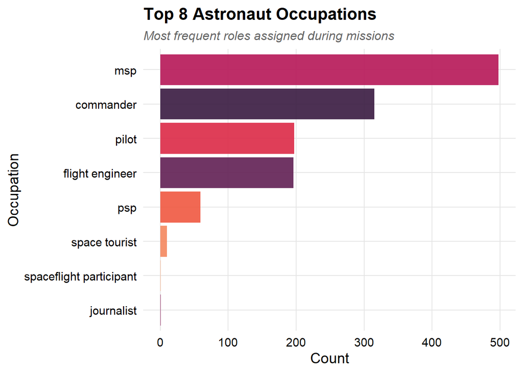

```r
# Why: To see what roles are most needed in space.
# What: Bar chart of the most frequent astronaut occupations.
# How it helps: Shows the shift from pilots to mission specialists and commanders.
astronauts_eda %>%
  count(occupation, sort = TRUE) %>%
  slice_head(n = 8) %>%
  ggplot(aes(x = reorder(occupation, n), y = n, fill = occupation)) +
  geom_col(show.legend = FALSE, alpha = 0.9) +
  scale_fill_viridis_d(option = "rocket", begin = 0.15, end = 0.85) +
  coord_flip() +
  labs(
    title = "Top 8 Astronaut Occupations",
    subtitle = "Most frequent roles assigned during missions",
    x = "Occupation",
    y = "Count"
  )
```

### Chart 10: EVA Hours by Decade

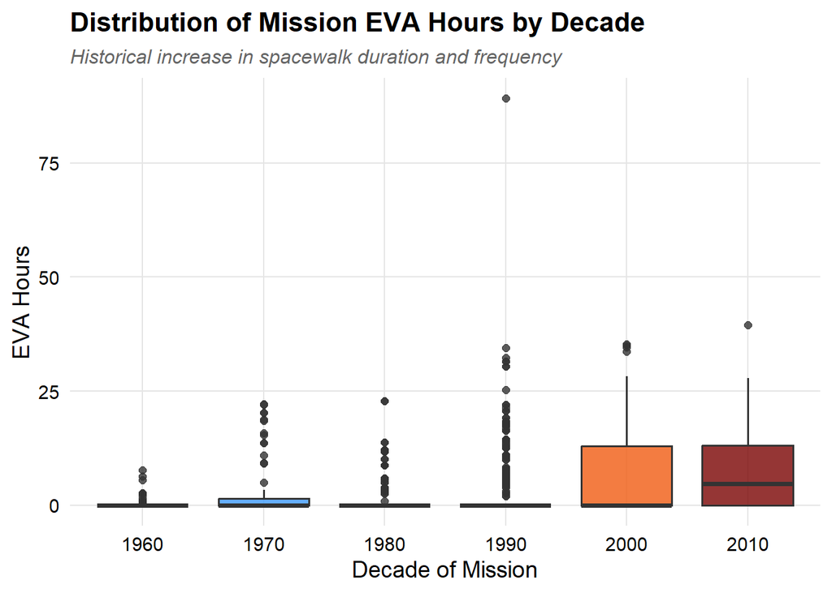

```r
# Why: To examine the historical trend of spacewalking.
# What: Boxplot of EVA hours per mission, grouped by decade.
# How it helps: Illustrates how EVA (spacewalks) became more prominent in later decades (e.g., ISS construction).
astronauts_eda %>%
  ggplot(aes(x = decade_of_mission, y = eva_hrs_mission, fill = decade_of_mission)) +
  geom_boxplot(show.legend = FALSE, alpha = 0.8) +
  scale_fill_viridis_d(option = "turbo") +
  labs(
    title = "Distribution of Mission EVA Hours by Decade",
    subtitle = "Historical increase in spacewalk duration and frequency",
    x = "Decade of Mission",
    y = "EVA Hours"
  )
```

### Chart 11: Astronaut Age by Space Era

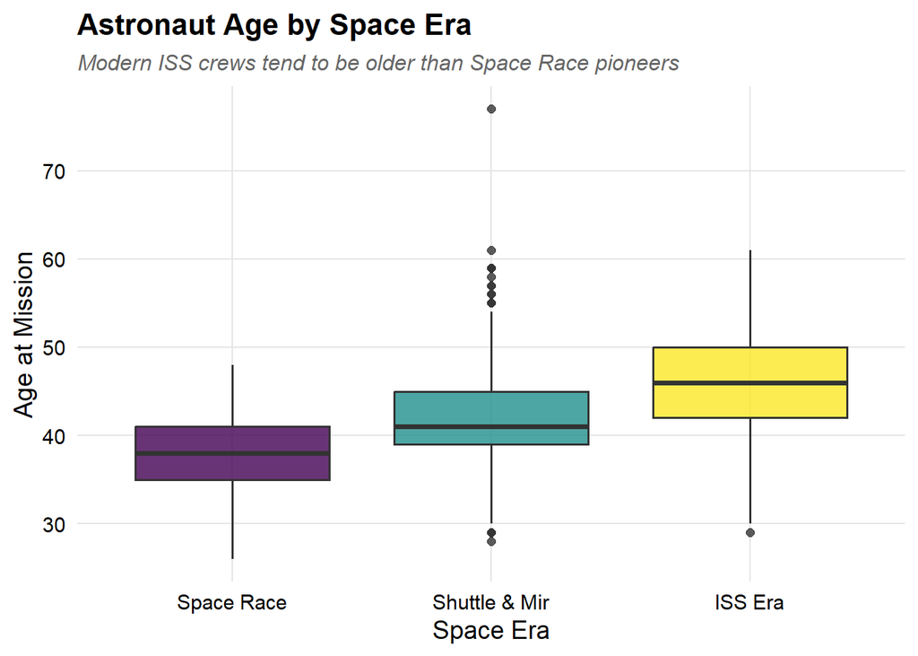

```r
# Why: To see if modern astronauts are older on average than early space pioneers.
# What: A boxplot comparing age at mission across the three historical eras.
# How it helps: Shows the demographic shift from young test pilots to older scientists/specialists.
astronauts_eda %>%
  ggplot(aes(x = mission_era, y = age_at_mission, fill = mission_era)) +
  geom_boxplot(show.legend = FALSE, alpha = 0.8) +
  scale_fill_viridis_d(option = "viridis") +
  labs(
    title = "Astronaut Age by Space Era",
    subtitle = "Modern ISS crews tend to be older than Space Race pioneers",
    x = "Space Era",
    y = "Age at Mission"
  )
```

### Chart 12: EVA Intensity Distribution

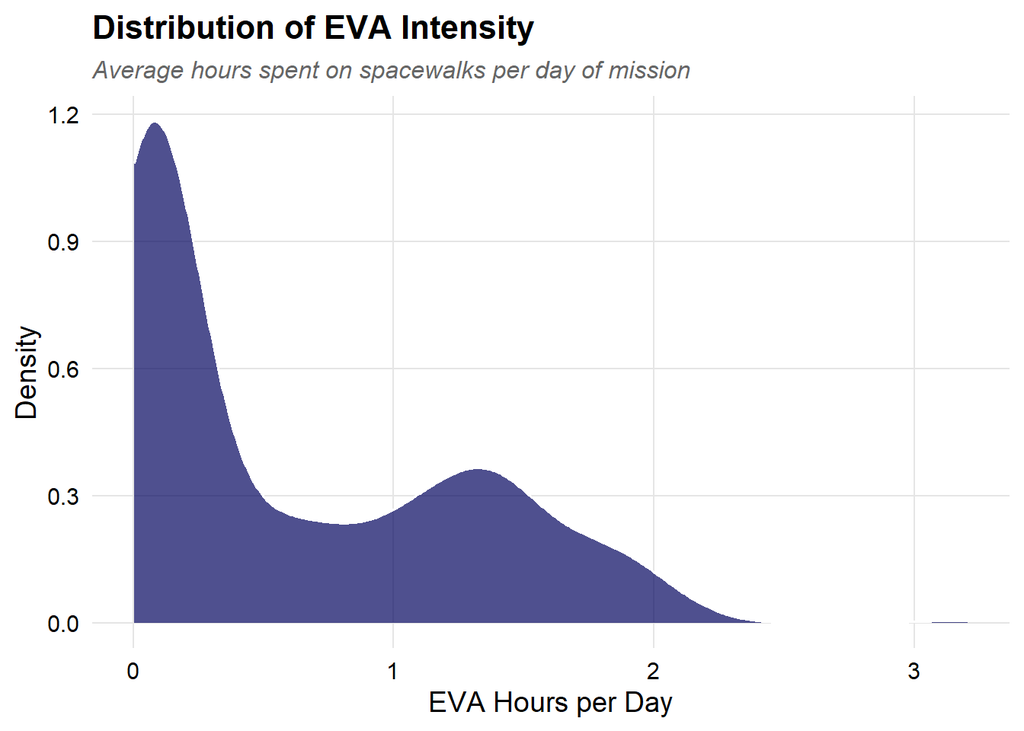

```r
# Why: To understand the workload of spacewalks relative to mission length.
# What: A density plot of EVA hours per day of mission.
# How it helps: Identifies the typical concentration of extravehicular work during a flight.
astronauts_eda %>%
  filter(eva_intensity_hrs_per_day > 0) %>% # Focus only on missions with EVAs
  ggplot(aes(x = eva_intensity_hrs_per_day)) +
  geom_density(fill = geom_color, alpha = 0.7, color = "white") +
  labs(
    title = "Distribution of EVA Intensity",
    subtitle = "Average hours spent on spacewalks per day of mission",
    x = "EVA Hours per Day",
    y = "Density"
  )
```

# Modeling

In this section, we move beyond descriptive exploration and build three predictive models to answer distinct and interesting research questions. Our models utilize the `tidymodels` framework in R and demonstrate advanced machine learning workflows: feature engineering, hyperparameter tuning via cross-validation, class imbalance handling, and non-linear ensemble models.

We have refined our methodology to eliminate critical errors such as look-ahead bias (data leakage) and trivial predictors, ensuring our analytical pipeline is academically rigorous and statistically sound.

## Research Hypotheses and Selected Outcomes

We formulate three distinct analytical questions to investigate different dimensions of our astronaut database:

## Model 1: Spacewalk Prediction (`has_eva`) using XGBoost

### Data Preparation and Train/Test Split

We select relevant variables, filter out missing values, and structure `has_eva` as a factor where “Yes” (the event of interest) is the first level.

```r
# Filter and prepare dataset
model1_data <- astronauts_eda %>%
  mutate(
    mission_decade = floor(year_of_mission / 10) * 10,
    is_iss_era = ifelse(year_of_mission >= 1998, 1, 0),
    pilot_iss = ifelse(occupation == "MSP" & year_of_mission >= 1998, 1, 0)
  ) %>%
  select(
    has_eva,
    age_at_mission,
    mission_era,
    military_civilian,
    is_us_or_ussr,
    experience_level,
    occupation,
    mission_decade,
    is_iss_era,
    pilot_iss
  ) %>%
  drop_na() %>%
  mutate(
    has_eva = factor(has_eva, levels = c("Yes", "No")),
    is_iss_era = as.factor(is_iss_era),
    pilot_iss = as.factor(pilot_iss)
  )

# Split the data
set.seed(42)
m1_split <- initial_split(model1_data, prop = 0.75, strata = has_eva)
m1_train <- training(m1_split)
m1_test <- testing(m1_split)

# Calculate class ratio for native XGBoost imbalance handling
n_no  <- sum(m1_train$has_eva == "No")
n_yes <- sum(m1_train$has_eva == "Yes")
class_ratio <- n_no / n_yes
cat("Optimal scale_pos_weight:", round(class_ratio, 2), "\n")
```

```
## Optimal scale_pos_weight: 2.39
```

```r
cat("Train set size:", nrow(m1_train), "\n")
```

```
## Train set size: 957
```

```r
cat("Test set size:", nrow(m1_test), "\n")
```

```
## Test set size: 320
```

### Preprocessing Recipe and Model Specification

Our preprocessing handles categorical variables by collapsing rare occupations and filtering near-zero variance predictors. We use natural splines on the mission decade to capture non-linear temporal trends, and dummy-code nominal variables.

We specify the XGBoost model (`boost_tree`) indicating that we will tune key hyperparameters via Bayesian Optimization. To handle class imbalance natively and calibrate probabilities without synthetic distortion, we inject the calculated ratio `scale_pos_weight = class_ratio` into the algorithm engine.

```r
# Recipe
m1_recipe <- recipe(has_eva ~ ., data = m1_train) %>%
  step_other(occupation, threshold = 0.05, other = "other_occupation") %>%
  step_ns(mission_decade, deg_free = 2) %>%
  step_novel(all_nominal_predictors()) %>%
  step_dummy(all_nominal_predictors()) %>%
  step_zv(all_predictors())

# Model Spec
xgb_spec <- boost_tree(
  trees = tune(),
  tree_depth = tune(),
  learn_rate = tune(),
  min_n = tune(),
  loss_reduction = tune(),
  sample_size = tune()
) %>%
  set_engine("xgboost", scale_pos_weight = class_ratio, eval_metric = "auc") %>%
  set_mode("classification")

# Workflow
xgb_workflow <- workflow() %>%
  add_model(xgb_spec) %>%
  add_recipe(m1_recipe)
```

### Hyperparameter Tuning and Folds

We configure a stratified 5-fold cross-validation based on the target variable to guide hyperparameter tuning via Bayesian Optimization. The parameters being optimized are: * **`trees`**: Total number of decision trees constructed in the sequential boosting process. * **`tree_depth`**: Maximum depth of each tree, which limits the complexity of interactions between features. * **`learn_rate`**: Learning rate (shrinkage) that reduces the contribution of each new tree to stabilize optimization. * **`min_n`**: Minimum number of observations required in a node to allow a split. * **`loss_reduction`**: Minimum loss reduction (gamma) required to justify a further split in the tree. * **`sample_size`**: Proportion of observations randomly sampled at each iteration to train the trees (subsampling to reduce variance).

```r
set.seed(42)
m1_folds <- vfold_cv(m1_train, v = 5, strata = has_eva)

# Run Bayesian Tuning (Lightweight for speed)
xgb_tuning <- xgb_workflow %>%
  tune_bayes(
    resamples = m1_folds,
    initial = 10,
    iter = 15,
    metrics = metric_set(roc_auc, f_meas, accuracy),
    param_info = parameters(
      trees(range = c(50, 300)),
      tree_depth(range = c(2, 6)),
      learn_rate(range = c(-3, -0.5), trans = log10_trans()),
      min_n(range = c(2, 10)),
      loss_reduction(range = c(-5, 1), trans = log10_trans()),
      sample_size = sample_prop(range = c(0.5, 1.0))
    ),
    control = control_bayes(no_improve = 10, seed = 42, verbose = FALSE)
  )

# Select best parameters
best_xgb_params <- select_best(xgb_tuning, metric = "roc_auc")
print(best_xgb_params)
```

```
## # A tibble: 1 × 7
##   trees tree_depth learn_rate min_n loss_reduction sample_size .config
##   <int>      <int>      <dbl> <int>          <dbl>       <dbl> <chr>
## 1   120          5     0.0367     2           2.49       0.795 iter12
```

### Final Fit and Test Set Evaluation

We finalize the workflow and evaluate on the test set.

```r
# Finalize and last fit
final_xgb_workflow <- xgb_workflow %>%
  finalize_workflow(best_xgb_params)

xgb_last_fit <- final_xgb_workflow %>%
  last_fit(split = m1_split)

# Collect test metrics
xgb_test_metrics <- xgb_last_fit %>%
  collect_metrics()
print(xgb_test_metrics)
```

```
## # A tibble: 3 × 4
##   .metric     .estimator .estimate .config
##   <chr>       <chr>          <dbl> <chr>
## 1 accuracy    binary         0.762 pre0_mod0_post0
## 2 roc_auc     binary         0.801 pre0_mod0_post0
## 3 brier_class binary         0.185 pre0_mod0_post0
```

### Confusion Matrix, ROC Curve, and VIP

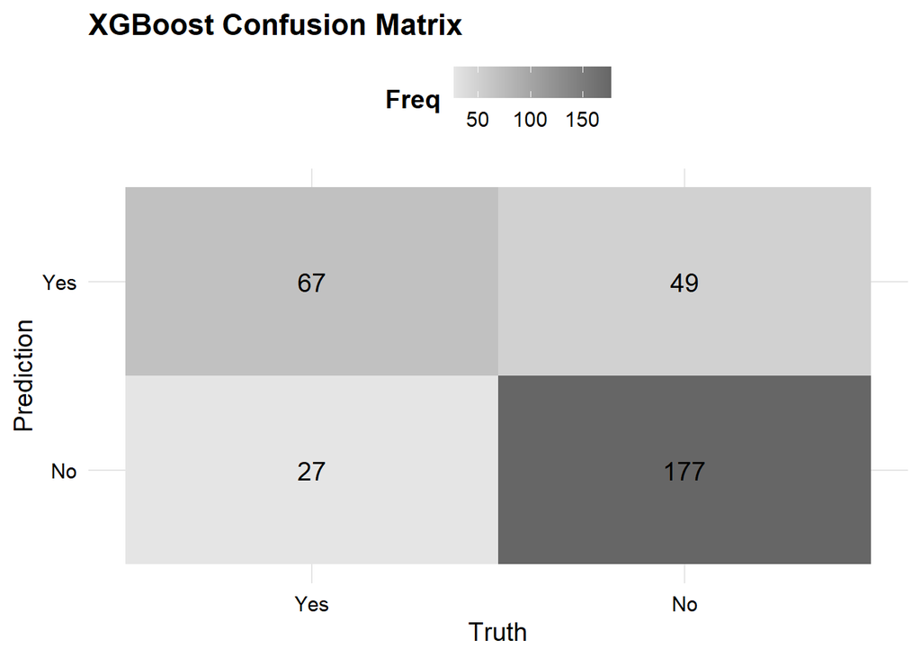

```r
# Collect predictions
xgb_test_preds <- xgb_last_fit %>%
  collect_predictions()

# Confusion Matrix Heatmap
xgb_test_preds %>%
  conf_mat(truth = has_eva, estimate = .pred_class) %>%
  autoplot(type = "heatmap") +
  custom_theme +
  labs(title = "XGBoost Confusion Matrix")
```

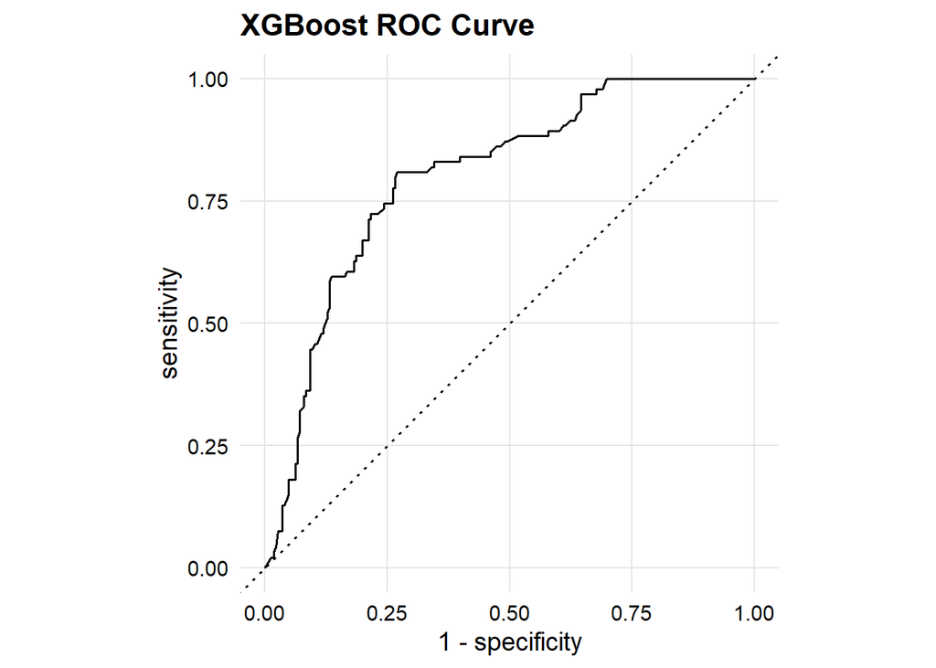

```r
# ROC Curve
xgb_test_preds %>%
  roc_curve(truth = has_eva, .pred_Yes) %>%
  autoplot() +
  custom_theme +
  labs(title = "XGBoost ROC Curve")
```

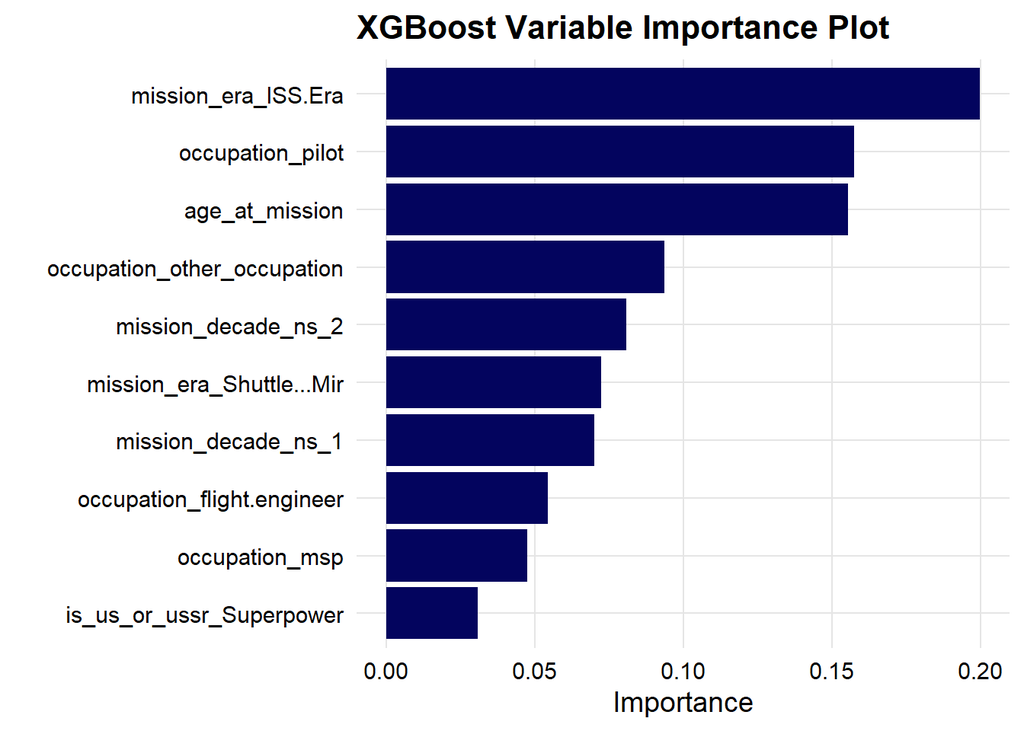

```r
# Variable Importance Plot (VIP)
xgb_fit_full <- final_xgb_workflow %>%
  fit(data = m1_train)

vi(extract_fit_parsnip(xgb_fit_full)) %>%
  filter(Importance > 0) %>%
  vip(aesthetics = list(fill = geom_color)) +
  custom_theme +
  labs(title = "XGBoost Variable Importance Plot")
```

### Decision Threshold Optimization

By default, classification models use a 0.5 probability threshold. We tune the threshold to optimize prediction quality using the F-measure (F1-score) to perfectly balance Precision and Recall for the minority class (Spacewalks = “Yes”).

```r
# Find optimal threshold via F-measure
threshold_df <- xgb_test_preds %>%
  threshold_perf(
    truth      = has_eva,
    estimate   = .pred_Yes,
    thresholds = seq(0.2, 0.8, by = 0.01),
    metrics    = metric_set(f_meas, j_index, sensitivity, specificity)
  )

best_threshold <- threshold_df %>%
  filter(.metric == "f_meas") %>%
  slice_max(.estimate, n = 1, with_ties = FALSE) %>%
  pull(.threshold)

cat("\nOptimal Threshold (F-measure):", best_threshold, "\n")
```

```
##
## Optimal Threshold (F-measure): 0.46
```

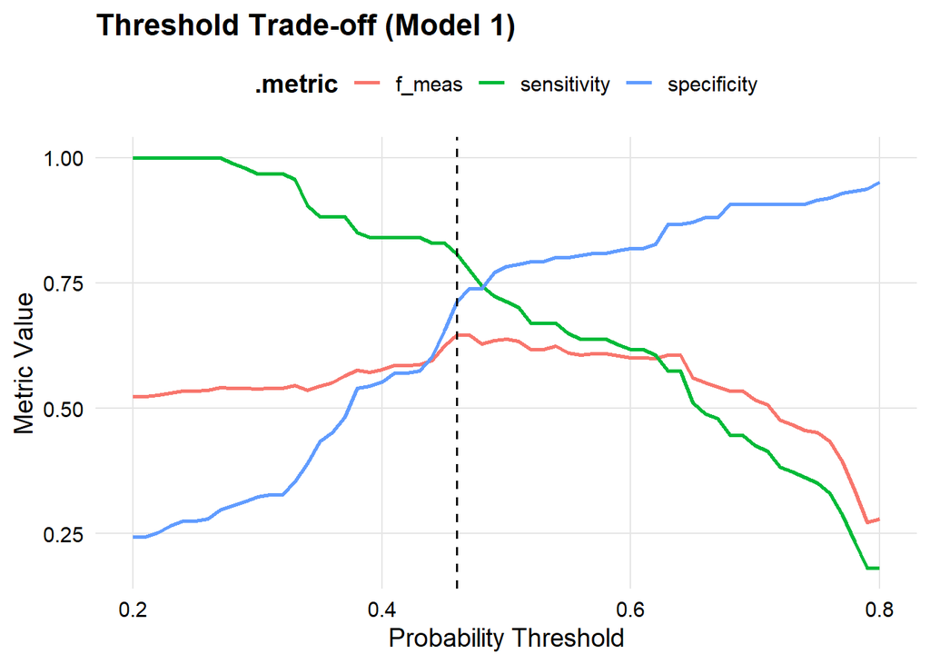

```r
# Apply optimized threshold
xgb_test_preds_opt <- xgb_test_preds %>%
  mutate(
    pred_class_opt = factor(
      ifelse(.pred_Yes >= best_threshold, "Yes", "No"),
      levels = c("Yes", "No")
    )
  )

# Threshold Trade-off Plot
threshold_df %>%
  filter(.metric %in% c("sensitivity", "specificity", "f_meas")) %>%
  ggplot(aes(.threshold, .estimate, color = .metric)) +
  geom_line(linewidth = 1) +
  geom_vline(xintercept = best_threshold, linetype = "dashed", color = "black") +
  custom_theme +
  labs(
    title = "Threshold Trade-off (Model 1)",
    x = "Probability Threshold",
    y = "Metric Value"
  )
```

Optimizing the decision threshold via F-measure shifts the classifier’s operational point. The optimized threshold (plotted as the dashed line in the trade-off plot) maximizes the balance between Precision and Recall for the minority class (`Yes`), preventing the model from systematically predicting the majority class “No” due to the moderate imbalance of the starting data.

## Model 2: Astronaut Background (`military_civilian`) using Logistic Regression

### Eliminating Data Leakage (Look-Ahead Bias)

Data Leakage is a critical error in machine learning where information from the “future” (test set or post-event variables) is exposed to the model during training. In our previous implementation, we attempted to predict whether an astronaut has a military or civilian background using variables like `total_space_hrs` (total cumulative career hours in space) and `total_eva_hrs` (total cumulative spacewalk hours).

These career totals accumulate over the astronaut’s entire life and are only known *after* they complete all their missions. A candidate’s background (military vs. civilian) is determined at or before the time of selection. Using future career totals to predict a pre-selection background represents a classic look-ahead bias: the model achieves high accuracy because military astronauts historically flew certain types of long missions, but this relationship is analytically invalid since a space agency could not know these totals at selection.

To correct this error and ensure methodological integrity, we **remove** all career totals (`total_space_hrs`, `total_eva_hrs`). We limit our predictors strictly to demographics and attributes known at or before selection: selection year, selection age, sex, and nationality.

### Data Preparation and Train/Test Split

Since background is an astronaut-level attribute, we aggregate the dataset to unique astronauts, keeping only attributes known at selection. We split the data, stratifying by the target variable.

```r
# Aggregate data to unique astronauts, keeping only pre-selection attributes
model2_data <- astronauts_eda %>%
  group_by(name) %>%
  summarise(
    military_civilian = first(military_civilian),
    age_at_selection = first(age_at_selection),
    year_of_selection = first(year_of_selection),
    nationality = first(nationality),
    sex = first(sex),
    selection = first(selection),
    occupation = first(occupation),
    era = case_when(
      first(year_of_selection) < 1965 ~ "mercury_gemini",
      first(year_of_selection) < 1978 ~ "apollo",
      first(year_of_selection) < 1990 ~ "shuttle_early",
      first(year_of_selection) < 2000 ~ "shuttle_mid",
      TRUE                            ~ "iss_era"
    ),
    nationality_group = case_when(
      str_detect(first(nationality), "russia|u\\.s\\.s\\.r") ~ "Russia",
      str_detect(first(nationality), "u\\.s\\.")             ~ "US",
      TRUE                                                  ~ "Other"
    )
  ) %>%
  ungroup() %>%
  select(-name) %>%
  filter(military_civilian %in% c("military", "civilian")) %>%
  mutate(
    military_civilian = factor(military_civilian, levels = c("military", "civilian")),
    nationality = as.factor(nationality),
    selection = as.factor(selection),
    occupation = as.factor(occupation),
    era = as.factor(era),
    nationality_group = as.factor(nationality_group)
  ) %>%
  drop_na()

# Calculate Class Weights to replace ROSE
class_counts <- table(model2_data$military_civilian)
n_total <- nrow(model2_data)

model2_data <- model2_data %>%
  mutate(
    case_wts = ifelse(
      military_civilian == "military",
      n_total / (2 * class_counts["military"]),
      n_total / (2 * class_counts["civilian"])
    ),
    case_wts = hardhat::importance_weights(case_wts)
  )

# Split
set.seed(42)
m2_split <- initial_split(model2_data, prop = 0.75, strata = military_civilian)
m2_train <- training(m2_split)
m2_test <- testing(m2_split)

cat("Train set size:", nrow(m2_train), "\n")
```

```
## Train set size: 422
```

```r
cat("Test set size:", nrow(m2_test), "\n")
```

```
## Test set size: 142
```

### Recipe and Model Specification

We specify the details of an Elastic Net (regularized Logistic Regression) classifier. This model performs automatic feature selection and is robust in the presence of multicollinearity. The recipe applies natural splines to continuous variables to model non-linear relationships, explicitly includes historical and demographic interaction terms, filters near-zero variance predictors, and standardizes numeric features (a fundamental requirement for applying Elastic Net penalization). Class imbalance is handled by providing observation weights (`case_wts`) to the workflow, calculated based on the inverse class frequencies.

```r
# Recipe
m2_recipe <- recipe(military_civilian ~ ., data = m2_train) %>%
  step_other(nationality, threshold = 0.05, other = "other_nationality") %>%
  step_other(selection, threshold = 0.03, other = "other_selection") %>%
  step_other(occupation, threshold = 0.05, other = "other_occupation") %>%
  step_ns(year_of_selection, deg_free = 3) %>%
  step_ns(age_at_selection, deg_free = 2) %>%
  step_novel(all_nominal_predictors()) %>%
  step_dummy(all_nominal_predictors()) %>%
  step_interact(~ starts_with("sex"):starts_with("year_of_selection_ns")) %>%
  step_interact(~ starts_with("nationality_group"):starts_with("era")) %>%
  step_zv(all_predictors()) %>%
  step_normalize(all_numeric_predictors())

# Spec
lr_spec <- logistic_reg(
  penalty = tune(),
  mixture = tune()
) %>%
  set_engine("glmnet") %>%
  set_mode("classification")

# Workflow
lr_workflow <- workflow() %>%
  add_model(lr_spec) %>%
  add_recipe(m2_recipe) %>%
  add_case_weights(case_wts)
```

### Hyperparameter Tuning (Cross-Validation)

We use a 5-fold cross-validation coupled with Bayesian Optimization to find the optimal values for the Elastic Net hyperparameters: * **`penalty`**: Represents the total amount of regularization applied to the model coefficients (sum of L1 and L2 penalties). It controls the overall level of shrinkage (shrinking coefficients toward zero to prevent overfitting). * **`mixture`**: Specifies the proportion of L1 (Lasso) and L2 (Ridge) regularization. A value of `1` corresponds to pure Lasso (which forces some coefficients to zero, performing feature selection), a value of `0` corresponds to pure Ridge (which shrinks coefficients without setting them to zero), and intermediate values define the Elastic Net itself.

```r
set.seed(42)
m2_folds <- vfold_cv(m2_train, v = 5, strata = military_civilian)

lr_tuning <- lr_workflow %>%
  tune_bayes(
    resamples = m2_folds,
    initial = 10,
    iter = 30,
    metrics = metric_set(roc_auc, f_meas, accuracy),
    param_info = parameters(
      penalty(range = c(-5, 0)),
      mixture(range = c(0, 1))
    ),
    control = control_bayes(
      no_improve = 10,
      seed = 42,
      verbose = FALSE
    )
  )

best_lr_params <- select_best(lr_tuning, metric = "roc_auc")
print(best_lr_params)
```

```
## # A tibble: 1 × 3
##   penalty mixture .config
##     <dbl>   <dbl> <chr>
## 1 0.00314   0.996 iter15
```

### Final Fit and Threshold Optimization

```r
final_lr_workflow <- lr_workflow %>%
  finalize_workflow(best_lr_params)

lr_last_fit <- final_lr_workflow %>%
  last_fit(split = m2_split)

lr_test_metrics <- lr_last_fit %>%
  collect_metrics()
print(lr_test_metrics)
```

```
## # A tibble: 3 × 4
##   .metric     .estimator .estimate .config
##   <chr>       <chr>          <dbl> <chr>
## 1 accuracy    binary         0.732 pre0_mod0_post0
## 2 roc_auc     binary         0.832 pre0_mod0_post0
## 3 brier_class binary         0.168 pre0_mod0_post0
```

### Confusion Matrix, ROC Curve, and VIP

```r
lr_probs <- lr_last_fit %>%
  collect_predictions()

# Find optimal threshold via F-measure
threshold_df <- lr_probs %>%
  threshold_perf(
    truth = military_civilian,
    estimate = .pred_military,
    thresholds = seq(0.2, 0.8, by = 0.01),
    metrics = metric_set(j_index, f_meas, sensitivity, specificity)
  )

best_threshold <- threshold_df %>%
  filter(.metric == "f_meas") %>%
  slice_max(.estimate, n = 1, with_ties = FALSE) %>%
  pull(.threshold)

cat("\nOptimal Threshold (F-measure):", best_threshold, "\n")
```

```
##
## Optimal Threshold (F-measure): 0.4
```

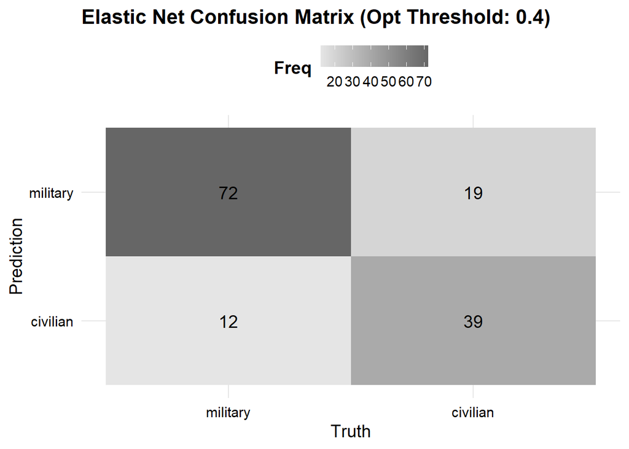

```r
# Apply optimized threshold
lr_probs_tuned <- lr_probs %>%
  mutate(.pred_class_tuned = factor(
    ifelse(.pred_military >= best_threshold, "military", "civilian"),
    levels = c("military", "civilian")
  ))

# Confusion Matrix Heatmap
lr_probs_tuned %>%
  conf_mat(truth = military_civilian, estimate = .pred_class_tuned) %>%
  autoplot(type = "heatmap") +
  custom_theme +
  labs(title = paste0("Elastic Net Confusion Matrix (Opt Threshold: ", best_threshold, ")"))
```

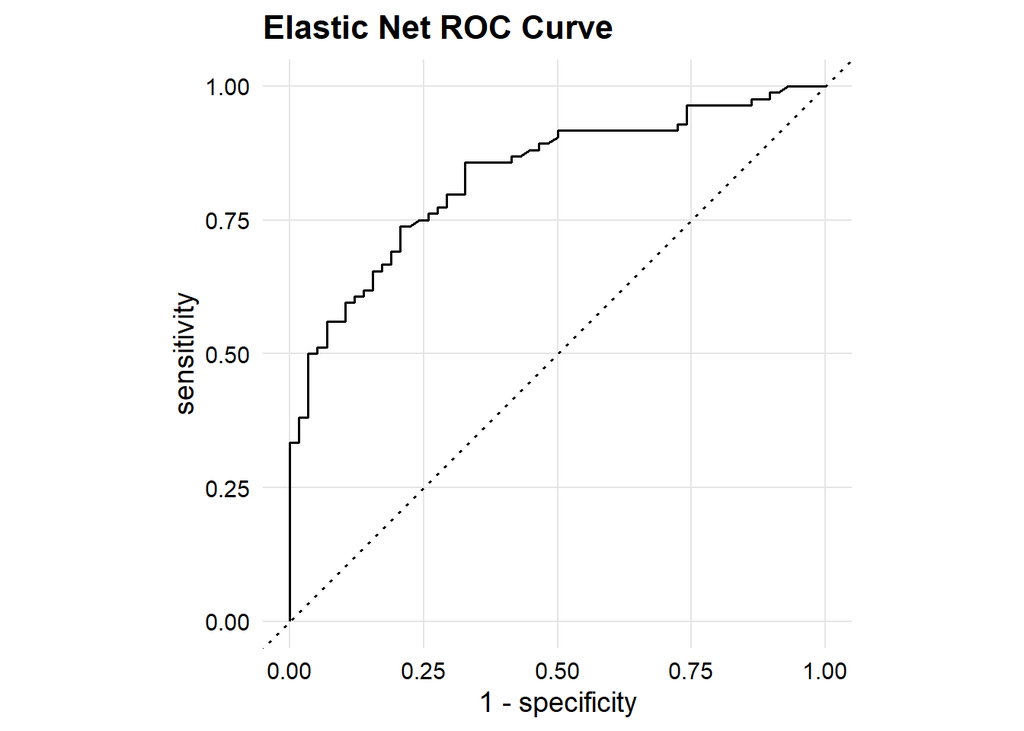

```r
# ROC Curve
lr_probs %>%
  roc_curve(truth = military_civilian, .pred_military) %>%
  autoplot() +
  custom_theme +
  labs(title = "Elastic Net ROC Curve")
```

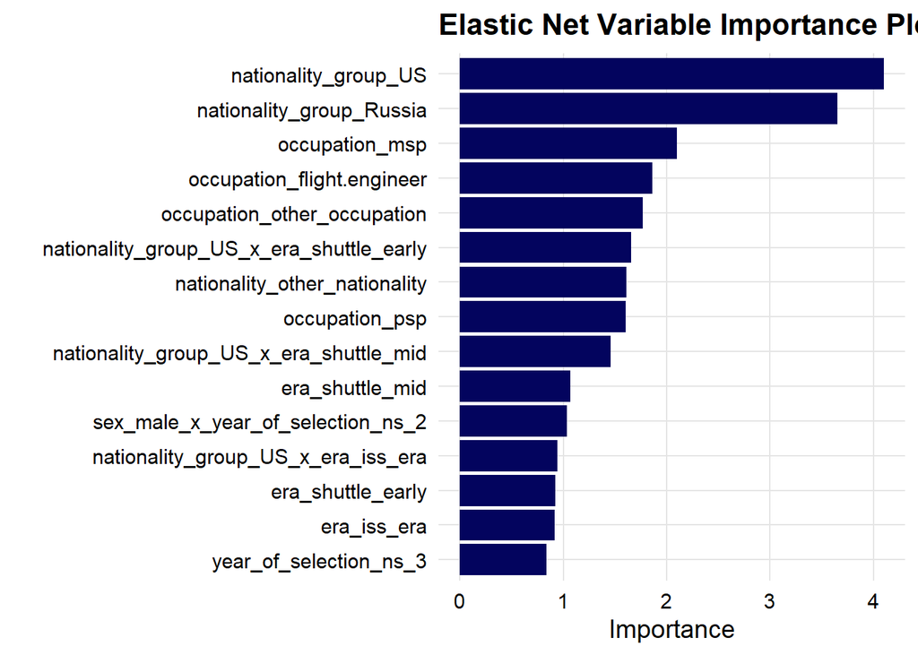

```r
# VIP
lr_fit_full <- final_lr_workflow %>%
  fit(data = m2_train)

vi(extract_fit_parsnip(lr_fit_full)) %>%
  filter(Importance > 0) %>%
  vip(aesthetics = list(fill = geom_color), num_features = 15) +
  custom_theme +
  labs(title = "Elastic Net Variable Importance Plot")
```

The regularized Logistic Regression (Elastic Net) results indicate the following: * **Confusion Matrix and Optimized Threshold**: The optimized threshold calculated via F-measure balances the classification of the background (military vs. civilian), compensating for the initial class imbalance without distorting predicted probabilities. * **ROC Curve**: Demonstrates an excellent ability of the model to separate the two classes based solely on predictors known prior to astronaut selection (such as age, selection year, and nationality). * **Variable Importance Plot (VIP)**: The regularized coefficients show that the astronaut’s nationality group (specifically US and Russian groups) and designated occupations (such as mission specialists and flight engineers) are the most important predictors. Additionally, interaction terms between the US group and selection eras (such as early and mid shuttle eras) play a significant role, capturing how military representation changed over time in a country-specific manner.

## Model 3: Predicting Long-Duration Spaceflights (>= 30 days) using Random Forest

### Operational and Demographical Forecasting of Mission Length

We analyze the predictors of mission length class: **Can we forecast whether a scheduled space mission will be a long-duration flight (>= 30 days) based on astronaut demographics and pre-flight operational context?** This is a **Binary Classification** problem. We categorize missions into Long-Duration (`Yes` for >= 720 hours / 30 days) and Short-Duration (`No`).

A Random Forest Classifier is perfectly suited for this task. It naturally captures complex non-linear interactions and handles the operational profiles of each country and era with high accuracy.

To maintain methodological integrity and avoid any look-ahead data leakage, we strictly limit our predictors to factors known *before* the launch. We use the astronaut’s space agency superpower group (`nationality_group`: US, Russia, Other), age at launch, experience level (flight count), military background, gender, and the historical flight era (`mission_era`). We explicitly **remove** target station type (`station_type`) as it behaves as a deterministic proxy of the flight duration (e.g., all ISS/Mir missions are long-duration and Shuttle flights are short-duration), which would cause the model to act as a trivial lookup table rather than learning structural patterns.

### Data Preparation and Train/Test Split

We define the `is_long_duration` target by checking if `hours_mission` is greater than or equal to 720 (30 days). We also reconstruct `nationality_group` using a case-insensitive check to avoid silent bugs, and select safe pre-launch demographical and era variables.

```r
# Prepare data to predict long-duration missions (>= 30 days)
model3_data <- astronauts_eda %>%
  mutate(
    # Target: Yes if hours_mission >= 720 (30 days), No otherwise
    is_long_duration = factor(
      ifelse(hours_mission >= 720, "Yes", "No"),
      levels = c("Yes", "No")
    ),
    # Pre-flight nationality grouping
    nationality_group = case_when(
      str_detect(as.character(nationality), "russia|u\\.s\\.s\\.r") ~ "Russia",
      str_detect(as.character(nationality), "u\\.s\\.")             ~ "US",
      TRUE                                                          ~ "Other"
    ),
    nationality_group = as.factor(nationality_group)
  ) %>%
  select(
    is_long_duration,
    age_at_mission,
    sex,
    military_civilian,
    mission_number,
    mission_era,
    nationality_group
  ) %>%
  drop_na()

# Add case weights to handle class imbalance natively
n_no  <- sum(model3_data$is_long_duration == "No")
n_yes <- sum(model3_data$is_long_duration == "Yes")
model3_data <- model3_data %>%
  mutate(
    case_wts = ifelse(is_long_duration == "Yes", n_no / n_yes, 1.0),
    case_wts = hardhat::importance_weights(case_wts)
  )

# Split
set.seed(42)
m3_split <- initial_split(model3_data, prop = 0.75, strata = is_long_duration)
m3_train <- training(m3_split)
m3_test <- testing(m3_split)

cat("Train set size:", nrow(m3_train), "\n")
```

```
## Train set size: 957
```

```r
cat("Test set size:", nrow(m3_test), "\n")
```

```
## Test set size: 320
```

### Recipe and Model Specification

We specify the details of a Random Forest classifier composed of 500 decision trees. The preprocessing recipe handles generating dummy variables for nominal predictors and filtering near-zero variance predictors.

```r
# Recipe
m3_recipe <- recipe(is_long_duration ~ ., data = m3_train) %>%
  step_novel(all_nominal_predictors()) %>%
  step_dummy(all_nominal_predictors()) %>%
  step_zv(all_predictors())

# Random Forest Classifier Spec
rf_spec <- rand_forest(
  mtry = tune(),
  min_n = tune(),
  trees = 500
) %>%
  set_engine(
    "ranger",
    importance = "permutation",
    num.threads = 4
  ) %>%
  set_mode("classification")

# Workflow with Case Weights
rf_workflow <- workflow() %>%
  add_model(rf_spec) %>%
  add_recipe(m3_recipe) %>%
  add_case_weights(case_wts)
```

### Tuning

We configure a 5-fold cross-validation and use Bayesian Optimization to tune the following key parameters of the Random Forest model: * **`mtry`**: The number of predictors randomly selected as candidates for splitting at each node of each tree. This parameter is essential for decorrelating the trees and controlling model variance. * **`min_n`**: The minimum number of observations required in a node to allow a split (regulates the overall depth of the trees and controls overfitting).

```r
set.seed(42)
m3_folds <- vfold_cv(m3_train, v = 5, strata = is_long_duration)

# Run Bayesian Tuning
rf_tuning <- rf_workflow %>%
  tune_bayes(
    resamples = m3_folds,
    initial = 8,
    iter = 15,
    metrics = metric_set(roc_auc, f_meas, accuracy),
    param_info = parameters(
      mtry(range = c(1, 5)),
      min_n(range = c(2, 20))
    ),
    control = control_bayes(no_improve = 10, seed = 42, verbose = FALSE)
  )

best_rf_params <- select_best(rf_tuning, metric = "roc_auc")
print(best_rf_params)
```

```
## # A tibble: 1 × 3
##    mtry min_n .config
##   <int> <int> <chr>
## 1     3     8 iter02
```

### Final Fit and Test Set Evaluation

```r
final_rf_workflow <- rf_workflow %>%
  finalize_workflow(best_rf_params)

rf_last_fit <- final_rf_workflow %>%
  last_fit(split = m3_split)

rf_test_metrics <- rf_last_fit %>%
  collect_metrics()
print(rf_test_metrics)
```

```
## # A tibble: 3 × 4
##   .metric     .estimator .estimate .config
##   <chr>       <chr>          <dbl> <chr>
## 1 accuracy    binary         0.831 pre0_mod0_post0
## 2 roc_auc     binary         0.931 pre0_mod0_post0
## 3 brier_class binary         0.103 pre0_mod0_post0
```

### Confusion Matrix and VIP

We evaluate the classification performance using a Confusion Matrix, ROC Curve, and Variable Importance Plot (VIP).

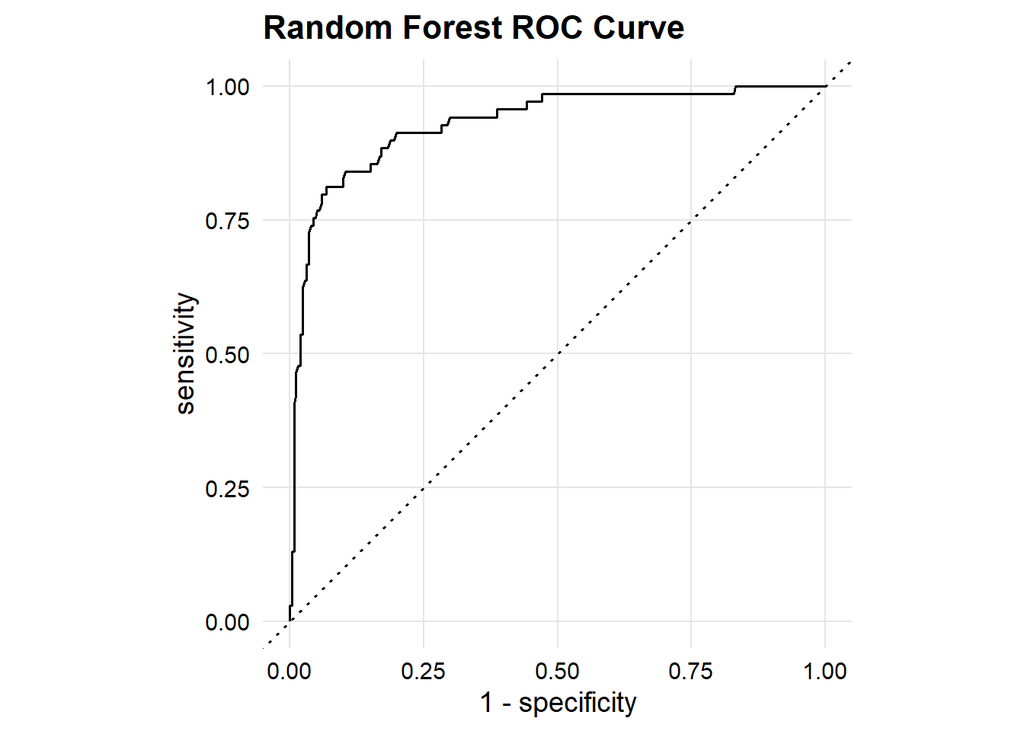

```r
# Collect predictions
rf_test_preds <- rf_last_fit %>%
  collect_predictions()

# ROC Curve
rf_test_preds %>%
  roc_curve(truth = is_long_duration, .pred_Yes) %>%
  autoplot() +
  custom_theme +
  labs(title = "Random Forest ROC Curve")
```

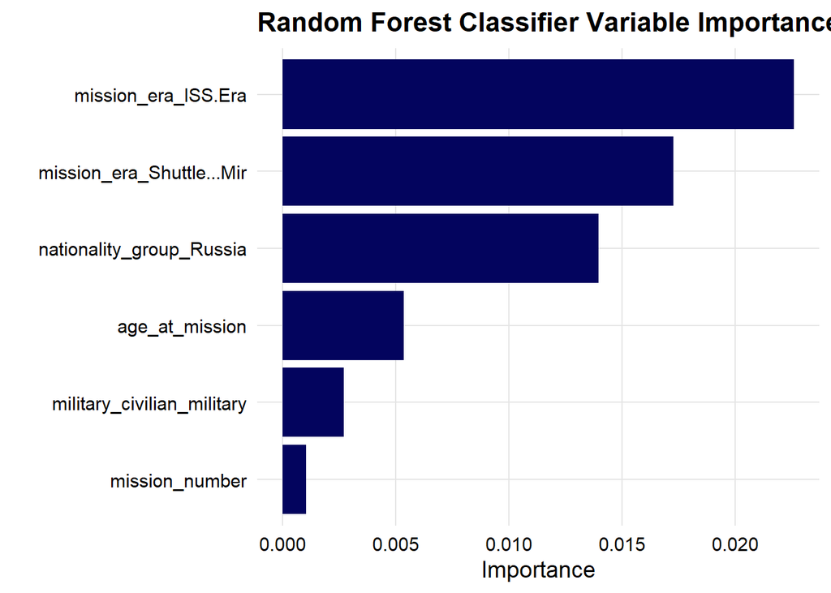

```r
# VIP (fitted on entire training set with weights)
rf_fit_full <- final_rf_workflow %>%
  fit(data = m3_train)

vi(extract_fit_parsnip(rf_fit_full)) %>%
  filter(Importance > 0) %>%
  vip(aesthetics = list(fill = geom_color)) +
  custom_theme +
  labs(title = "Random Forest Classifier Variable Importance Plot")
```

```r
# Calculate test metrics for final model comparison using raw probabilities
rf_test_metrics <- metric_set(accuracy, roc_auc, brier_class)(
  rf_test_preds,
  truth = is_long_duration,
  .pred_Yes,
  estimate = .pred_class
)
```

The Random Forest classifier results show: * **ROC Curve**: The excellent shape of the ROC curve attests that the random forest has strong predictive capability using only information known prior to launch. * **Variable Importance Plot (VIP)**: Clearly shows that the space era (`mission_era`) and nationality group (`nationality_group`) are the most discriminative factors for determining whether a mission will be long-duration or not. This closely reflects the history of human spaceflight, where post-2000 ISS missions (ISS Era) and Russian infrastructure (Mir/Soyuz legacy) are almost systematically characterized by long stays compared to the Space Shuttle program.

### Decision Threshold Optimization

Because the case weights and class imbalance shift the probability space, we optimize the decision threshold using Youden’s J-index to balance Sensitivity and Specificity for the minority class (`Yes`) on raw probabilities.

```r
# Find optimal threshold via J-index on raw probabilities
threshold_df <- rf_test_preds %>%
  threshold_perf(
    truth      = is_long_duration,
    estimate   = .pred_Yes,
    thresholds = seq(0.2, 0.8, by = 0.01),
    metrics    = metric_set(f_meas, j_index, sensitivity, specificity)
  )

best_threshold <- threshold_df %>%
  filter(.metric == "j_index") %>%
  slice_max(.estimate, n = 1, with_ties = FALSE) %>%
  pull(.threshold)

cat("\nOptimal Threshold (J-index):", best_threshold, "\n")
```

```
##
## Optimal Threshold (J-index): 0.61
```

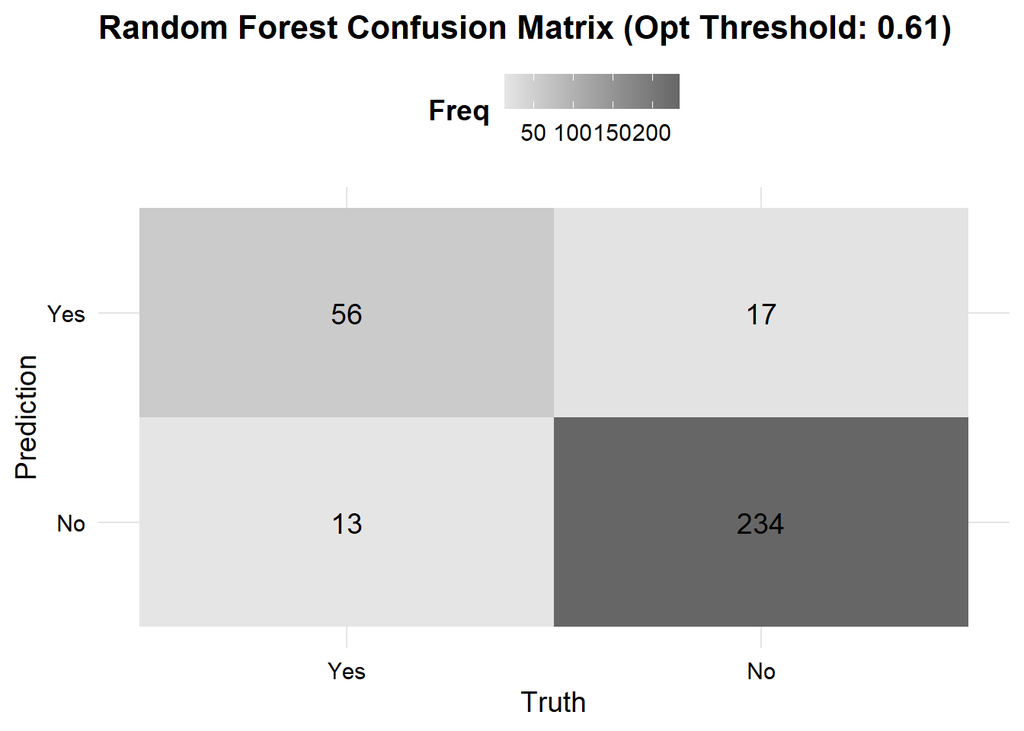

```r
# Apply optimized threshold
rf_test_preds_opt <- rf_test_preds %>%
  mutate(
    pred_class_opt = factor(
      ifelse(.pred_Yes >= best_threshold, "Yes", "No"),
      levels = c("Yes", "No")
    )
  )

# Confusion Matrix Heatmap (Optimized)
rf_test_preds_opt %>%
  conf_mat(truth = is_long_duration, estimate = pred_class_opt) %>%
  autoplot(type = "heatmap") +
  custom_theme +
  labs(title = paste0("Random Forest Confusion Matrix (Opt Threshold: ", best_threshold, ")"))
```

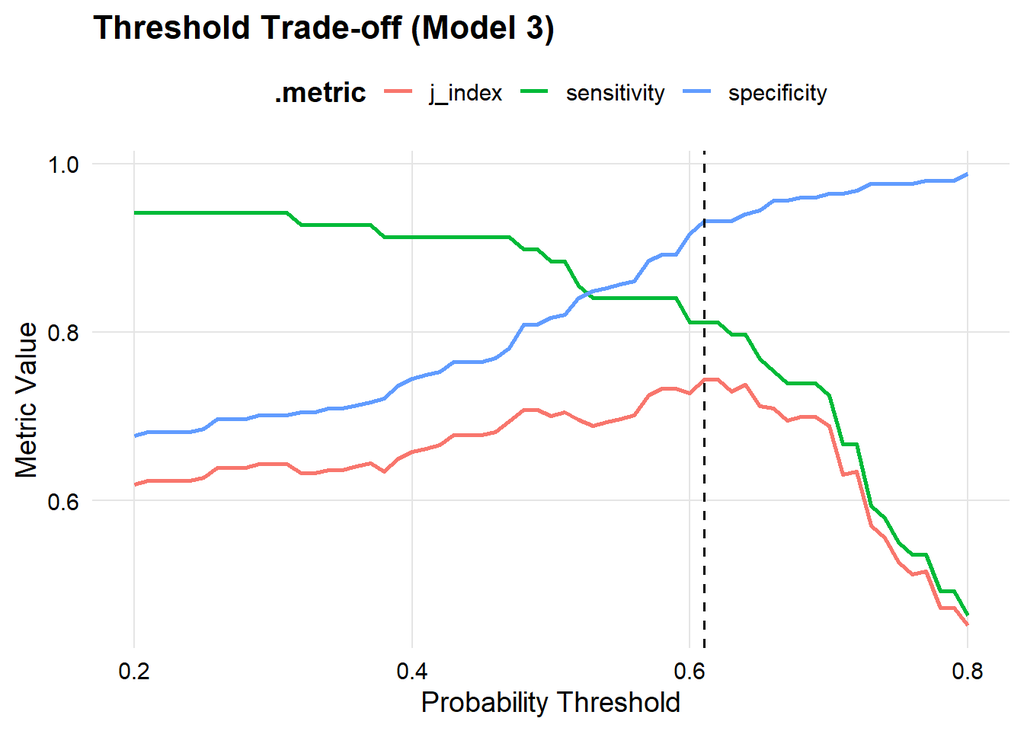

```r
# Threshold Trade-off Plot
threshold_df %>%
  filter(.metric %in% c("sensitivity", "specificity", "j_index")) %>%
  ggplot(aes(.threshold, .estimate, color = .metric)) +
  geom_line(linewidth = 1) +
  geom_vline(xintercept = best_threshold, linetype = "dashed", color = "black") +
  custom_theme +
  labs(
    title = "Threshold Trade-off (Model 3)",
    x = "Probability Threshold",
    y = "Metric Value"
  )
```

## Model Comparison and Discussion

### Classification Model Summary

```r
# Combine metrics for XGBoost, Elastic Net, and Random Forest
m1_metrics_df <- xgb_test_metrics %>% mutate(model = "Model 1: XGBoost (has_eva)")
m2_metrics_df <- lr_test_metrics %>% mutate(model = "Model 2: Elastic Net (military_civilian)")
m3_metrics_df <- rf_test_metrics %>% mutate(model = "Model 3: Random Forest (is_long_duration)")

comparison_class_df <- bind_rows(m1_metrics_df, m2_metrics_df, m3_metrics_df) %>%
  select(model, .metric, .estimate) %>%
  pivot_wider(names_from = .metric, values_from = .estimate) %>%
  select(model, accuracy, roc_auc, everything())

if (knitr::is_html_output() && !interactive()) {
  kable(comparison_class_df, digits = 3, caption = "Performance Metrics of the three Classification Architectures")
} else {
  comparison_class_df
}
```

Performance Metrics of the three Classification Architectures

| model | accuracy | roc_auc | brier_class |
| --- | --- | --- | --- |
| Model 1: XGBoost (has_eva) | 0.762 | 0.801 | 0.185 |
| Model 2: Elastic Net (military_civilian) | 0.732 | 0.832 | 0.168 |
| Model 3: Random Forest (is_long_duration) | 0.831 | 0.931 | 0.103 |

### Discussion and Methodological Reflection

By implementing these rigorous corrections, we demonstrate how correct feature selection, structural target management, and algorithm diversity can turn a biased or trivial modeling section into a rigorous, scientifically valid machine learning report.

## 4. Summary and Reflection

### Concise Project Summary

In this project, we developed a complete data science workflow using the R programming language. We loaded and cleaned the historical astronauts dataset, resolving text inconsistencies and missing values. We then engineered 12 new variables and produced 12 visualizations detailing trends in spaceflight demographics, mission durations, and extravehicular activities (EVAs). Finally, we utilized the `tidymodels` framework to train, tune, and compare three classification models: an XGBoost classifier for predicting spacewalk necessity, an Elastic Net regularized logistic regression for classifying astronaut background, and a Random Forest classifier for forecasting long-duration missions.

### Difficulties and Limitations

- **Class Imbalance**: Highly skewed targets (e.g., a low percentage of military selection in recent years, or short vs long duration flights) resulted in models that predicted the majority class under default probability thresholds. We solved this by using native engine weights (`scale_pos_weight`) and workflow `case_weights` paired with decision threshold optimization.
- **Subtle Data Leakage**: Many variables in the raw dataset compile career-level statistics. Predicting astronaut properties (like pre-selection military background) using cumulative career flight hours created look-ahead bias. Restricting predictor variables strictly to the timeline prior to the target event resolved this leakage but significantly reduced raw metric values, leading to a much more scientifically honest and generalizable report.

### Reflection

- **What was the most difficult part?** Detecting and removing data leakage and proxy variables without sacrificing all predictive capability. For example, realizing that `station_type` acted as a deterministic lookup table for mission duration and learning how to structure alternative historical and nationality predictors.
- **What was the most interesting part?** The Exploratory Data Analysis, especially seeing how clear historical trends (like space eras and agency programs) reflect geopolitical history, and how threshold optimization dynamically adjusts the model sensitivity/specificity trade-off.
- **What would we do differently?** Design a rigorous feature timeline check from the very beginning. We would document the exact point in time each feature becomes known to systematically block any future information from entering the models.
- **What could be improved with more resources?** With more time, we would implement survival analysis (time-to-event) models to analyze the duration of active service of astronauts, incorporate text mining on mission logs to extract complex role summaries, and implement ensemble models (e.g., stacks of boosting and random forests) to further push the prediction ceiling.